Home

# Introduction

Welcome to our notebook analyzing mental health data. Herein we will be working through various techniques in data analysis and/or [data science](https://en.wikipedia.org/wiki/Data_science). The datasets were found by the author on Kaggle. Please contact me for further information at Jgcblue9558@gmail.com

## Importing the data set and a cursory examination

```python
import pandas as pd


df_mental_health = pd.read_csv('prevalence-by-mental-and-substance-use-disorder.csv')

print(df_mental_health.head(2))

# Examine the columns

print(df_mental_health.columns)
```

```
        Entity Code  Year  \
0  Afghanistan  AFG  1990
1  Afghanistan  AFG  1991

   Prevalence - Schizophrenia - Sex: Both - Age: Age-standardized (Percent)  \
0                                           0.228979
1                                           0.228120

   Prevalence - Bipolar disorder - Sex: Both - Age: Age-standardized (Percent)  \
0                                           0.721207
1                                           0.719952

   Prevalence - Eating disorders - Sex: Both - Age: Age-standardized (Percent)  \
0                                           0.131001
1                                           0.126395

   Prevalence - Anxiety disorders - Sex: Both - Age: Age-standardized (Percent)  \
0                                           4.835127
1                                           4.821765

   Prevalence - Drug use disorders - Sex: Both - Age: Age-standardized (Percent)  \
0                                           0.454202
1                                           0.447112

   Prevalence - Depressive disorders - Sex: Both - Age: Age-standardized (Percent)  \
0                                           5.125291
1                                           5.116306

   Prevalence - Alcohol use disorders - Sex: Both - Age: Age-standardized (Percent)
0                                           0.444036
1                                           0.444250
Index(['Entity', 'Code', 'Year',
       'Prevalence - Schizophrenia - Sex: Both - Age: Age-standardized (Percent)',
       'Prevalence - Bipolar disorder - Sex: Both - Age: Age-standardized (Percent)',
       'Prevalence - Eating disorders - Sex: Both - Age: Age-standardized (Percent)',
       'Prevalence - Anxiety disorders - Sex: Both - Age: Age-standardized (Percent)',
       'Prevalence - Drug use disorders - Sex: Both - Age: Age-standardized (Percent)',
       'Prevalence - Depressive disorders - Sex: Both - Age: Age-standardized (Percent)',
       'Prevalence - Alcohol use disorders - Sex: Both - Age: Age-standardized (Percent)'],
      dtype='object')
```

As you can see the data set consists of Countries, Codes for said countries, years and the prevalence of various mental disorders in said country.

## Questions to Examine (Over the Long Haul)

Sure, here are some questions you might ask when analyzing data with columns like "Entity," "Code," "Year," and various prevalence rates for different mental health disorders across different sex and age groups:

1. What is the purpose of this dataset? Is it to track the prevalence of mental health disorders over time?
2. What is the significance of the "Entity" and "Code" columns? Do they represent countries or regions?
3. How is the "Prevalence" value calculated for each mental health disorder? Is it a percentage?
4. How is the "Age-standardized" prevalence calculated? Why is age standardization important in this context?
5. Can you explain the differences between the prevalence rates for different mental health disorders? Are certain disorders more common than others?
6. What trends can you observe in the prevalence rates over the years? Are there any notable changes or patterns?
7. Are there any significant differences in the prevalence rates between genders (Sex: Both) for each mental health disorder?
8. How do the prevalence rates for different mental health disorders change with age? Are there any age groups more susceptible to certain disorders?
9. What insights can you gather from the data regarding the mental health situation globally or within specific regions?
10. Are there any outlier years or values that seem unusual compared to the overall trends? What might explain these outliers?
11. How consistent is the data collection process across different countries or entities? Are there any data gaps or missing years?
12. Can you identify any correlations between the prevalence rates of different mental health disorders? Do they tend to increase or decrease together?
13. Are there any years or periods where there's a significant change in the prevalence rates? What events or factors might have contributed to these changes?
14. How might changes in mental health awareness, healthcare policies, or socioeconomic conditions impact the prevalence rates over time?
15. Are there any limitations to this dataset that should be considered when interpreting the results?
16. Can you provide any insights into the reliability and accuracy of the data sources used to compile this dataset?
17. How might researchers or policymakers use this data to inform mental health interventions and strategies?
18. Are there any plans to update this dataset with more recent years or include additional variables for a more comprehensive analysis?

These questions can help guide your exploration of the dataset and provide a deeper understanding of the mental health prevalence trends and patterns it contains.

## Shape

Its often useful to get a hold of the shape of a dataframe so that we know how much data we will be working and if we might have to do some "batch processing".

```python
df_mental_health.shape
#pd.reset_option('display.max_rows')
```

```
(6840, 10)
```

We read 6840 rows and 10 columns. This is managable enough so we won't think about it any more.

Now let's take a look at my home and what's happening when it comes to these disorders.

# United States and Answering Some Questions

We import matplotlib's pyplot and create a sub dataframe consisting of entries where the country is the United States.

```python
import pandas as pd
import matplotlib.pyplot as plt

# Load your data into a DataFrame
# data = pd.read_csv('your_data.csv')

# Filter data for the United States
usa_data = df_mental_health[df_mental_health['Entity'] == 'United States']

print(usa_data.head())
```

```
             Entity Code  Year  \
6330  United States  USA  1990
6331  United States  USA  1991
6332  United States  USA  1992
6333  United States  USA  1993
6334  United States  USA  1994

      Prevalence - Schizophrenia - Sex: Both - Age: Age-standardized (Percent)  \
6330                                           0.467115
6331                                           0.472488
6332                                           0.477502
6333                                           0.481847
6334                                           0.485216

      Prevalence - Bipolar disorder - Sex: Both - Age: Age-standardized (Percent)  \
```

[output cut: 40 more lines]

Now in data processing it is often a good idea to separate the data into python structures. This can help with focusing on some particular features.

Below we create a column of strings. These strings are the disorders/features. We will be able to use this list to look at specific disorders and their relationships to other features including date.

```python
# Get a list of mental health disorder columns
disorder_columns = [
    'Prevalence - Schizophrenia - Sex: Both - Age: Age-standardized (Percent)',
    'Prevalence - Bipolar disorder - Sex: Both - Age: Age-standardized (Percent)',
    'Prevalence - Eating disorders - Sex: Both - Age: Age-standardized (Percent)',
    'Prevalence - Anxiety disorders - Sex: Both - Age: Age-standardized (Percent)',
    'Prevalence - Drug use disorders - Sex: Both - Age: Age-standardized (Percent)',
    'Prevalence - Depressive disorders - Sex: Both - Age: Age-standardized (Percent)',
    'Prevalence - Alcohol use disorders - Sex: Both - Age: Age-standardized (Percent)'
]
```

NExt we take a key step in understanding the data. We create a scatter plot where on the x-axis we have years and on the y-axis we have the prevalence of the various mental disorders at those years.

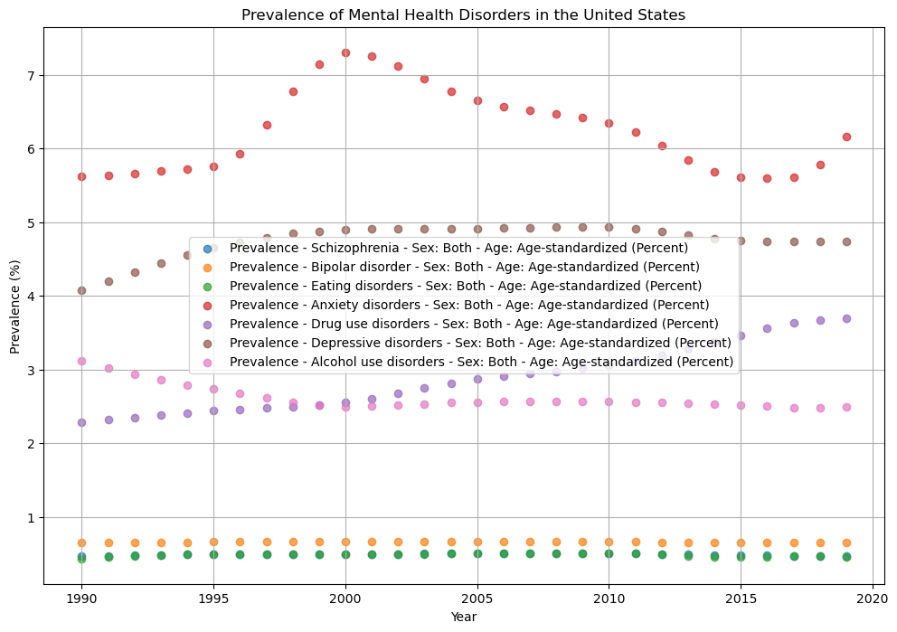

```python
# Create a scatter plot with different colors for each disorder
plt.figure(figsize=(12, 8))
for column in disorder_columns:
    plt.scatter(usa_data['Year'], usa_data[column], label=column, alpha=0.7)

plt.xlabel('Year')
plt.ylabel('Prevalence (%)')
plt.title('Prevalence of Mental Health Disorders in the United States')
plt.legend()
plt.grid(True)
plt.show()
```

As you can see there's a few interesting things to point out. Let's do that now before moving onto a friend and an interesting historical connection hinted at in our data.

## Disorders and Their Changes in Prevalences

Let's categorize roughly based off of visuals:

### stable

1. Bipolar
2. Eating

### Declining

*Alcohol Disorders

The fact that these disorders follow distinct trends is interesting perhaps it points to potential underlying mechanisms such as: genetics (stable), environmental (increasing and decreasing).

# Hello Neighbor... Mexico

Now I want to point out something that got my interest when I examined Mexico. Being of Mexican descent and being of the personal belief that appreciating one's culture is healthy and enjoyable I decided to look at Mexico's data (isolated).

```python
# Load your data into a DataFrame
# data = pd.read_csv('your_data.csv')

# Filter data for the United States
mex_data = df_mental_health[df_mental_health['Entity'] == 'Mexico']

print(mex_data.head(2))
```

```
      Entity Code  Year  \
3630  Mexico  MEX  1990
3631  Mexico  MEX  1991

      Prevalence - Schizophrenia - Sex: Both - Age: Age-standardized (Percent)  \
3630                                           0.292561
3631                                           0.292781

      Prevalence - Bipolar disorder - Sex: Both - Age: Age-standardized (Percent)  \
3630                                           0.950546
3631                                           0.951822

      Prevalence - Eating disorders - Sex: Both - Age: Age-standardized (Percent)  \
3630                                           0.234103
3631                                           0.236205

      Prevalence - Anxiety disorders - Sex: Both - Age: Age-standardized (Percent)  \
3630                                           2.993664
3631                                           2.994335

      Prevalence - Drug use disorders - Sex: Both - Age: Age-standardized (Percent)  \
3630                                           0.520234
3631                                           0.521305

      Prevalence - Depressive disorders - Sex: Both - Age: Age-standardized (Percent)  \
3630                                           3.165633
3631                                           3.185316

      Prevalence - Alcohol use disorders - Sex: Both - Age: Age-standardized (Percent)
3630                                           1.775613
3631                                           1.730985
```

Q: What would happen if we didn't feed 2 into the head method?

In the next cell I copied over our disorder columns- I didn't have to but I like seeing things in front of me when feasible) -and plotting a scatter plot analogous to the one I did for the U.S.

A: 5 lines would print

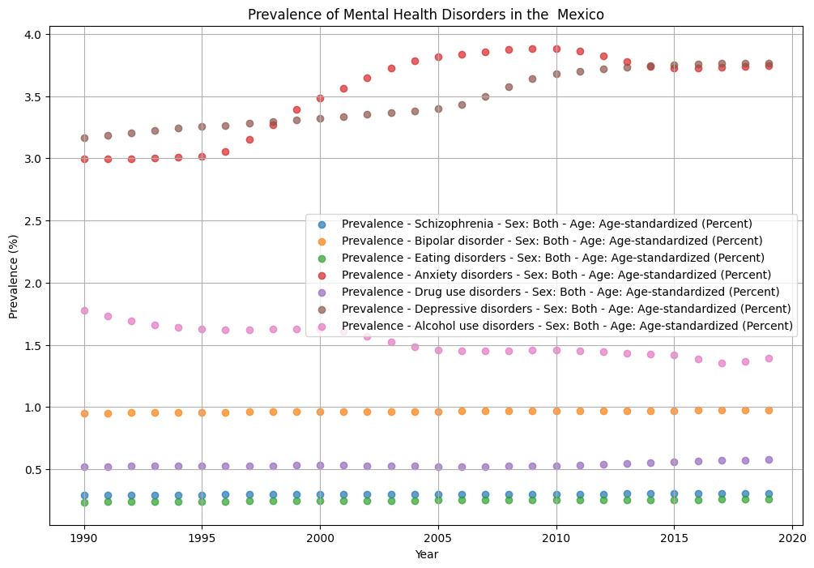

```python
disorder_columns = [
    'Prevalence - Schizophrenia - Sex: Both - Age: Age-standardized (Percent)',
    'Prevalence - Bipolar disorder - Sex: Both - Age: Age-standardized (Percent)',
    'Prevalence - Eating disorders - Sex: Both - Age: Age-standardized (Percent)',
    'Prevalence - Anxiety disorders - Sex: Both - Age: Age-standardized (Percent)',
    'Prevalence - Drug use disorders - Sex: Both - Age: Age-standardized (Percent)',
    'Prevalence - Depressive disorders - Sex: Both - Age: Age-standardized (Percent)',
    'Prevalence - Alcohol use disorders - Sex: Both - Age: Age-standardized (Percent)'
]


# Create a scatter plot with different colors for each disorder
plt.figure(figsize=(12, 8))
for column in disorder_columns:
    plt.scatter(mex_data['Year'], mex_data[column], label=column, alpha=0.7)

plt.xlabel('Year')
plt.ylabel('Prevalence (%)')
plt.title('Prevalence of Mental Health Disorders in the  Mexico')
plt.legend()
plt.grid(True)
plt.show()
```

As I have had some friends that lived in Mexico around that time seeing this data spurned the recall of a memory of a conversation I had with a friend a few years back.

I recalled that he shared some rather graphic and dangerous scenes that he witnessed in violence between the cartels and Mexico's army...while he was working in a Starbucks.

I seemed to recall that the years he was referring to be similar to 2007/2008 and low and behold upon an internet search I discovered that according to Wikipedia (and others sources) https://en.wikipedia.org/wiki/Mexican_drug_war this time period was known as an escalation time period when the government really tried to earnestly battle the cartels.

So it seems that we detected a major world event indirectly by examining this dataset!

```python
entities.unique()
```

```
array(['Afghanistan', 'African Region (WHO)', 'Albania', 'Algeria',
       'American Samoa', 'Andorra', 'Angola', 'Antigua and Barbuda',
       'Argentina', 'Armenia', 'Australia', 'Austria', 'Azerbaijan',
       'Bahamas', 'Bahrain', 'Bangladesh', 'Barbados', 'Belarus',
       'Belgium', 'Belize', 'Benin', 'Bermuda', 'Bhutan', 'Bolivia',
       'Bosnia and Herzegovina', 'Botswana', 'Brazil', 'Brunei',
       'Bulgaria', 'Burkina Faso', 'Burundi', 'Cambodia', 'Cameroon',
       'Canada', 'Cape Verde', 'Central African Republic', 'Chad',
       'Chile', 'China', 'Colombia', 'Comoros', 'Congo', 'Cook Islands',
       'Costa Rica', "Cote d'Ivoire", 'Croatia', 'Cuba', 'Cyprus',
       'Czechia', 'Democratic Republic of Congo', 'Denmark', 'Djibouti',
       'Dominica', 'Dominican Republic', 'East Asia & Pacific (WB)',
       'Eastern Mediterranean Region (WHO)', 'Ecuador', 'Egypt',
       'El Salvador', 'England', 'Equatorial Guinea', 'Eritrea',
       'Estonia', 'Eswatini', 'Ethiopia', 'Europe & Central Asia (WB)',
       'European Region (WHO)', 'Fiji', 'Finland', 'France', 'G20',
       'Gabon', 'Gambia', 'Georgia', 'Germany', 'Ghana', 'Greece',
       'Greenland', 'Grenada', 'Guam', 'Guatemala', 'Guinea',
       'Guinea-Bissau', 'Guyana', 'Haiti', 'Honduras', 'Hungary',
       'Iceland', 'India', 'Indonesia', 'Iran', 'Iraq', 'Ireland',
       'Israel', 'Italy', 'Jamaica', 'Japan', 'Jordan', 'Kazakhstan',
       'Kenya', 'Kiribati', 'Kuwait', 'Kyrgyzstan', 'Laos',
       'Latin America & Caribbean (WB)', 'Latvia', 'Lebanon', 'Lesotho',
       'Liberia', 'Libya', 'Lithuania', 'Luxembourg', 'Madagascar',
       'Malawi', 'Malaysia', 'Maldives', 'Mali', 'Malta',
       'Marshall Islands', 'Mauritania', 'Mauritius', 'Mexico',
       'Micronesia (country)', 'Middle East & North Africa (WB)',
       'Moldova', 'Monaco', 'Mongolia', 'Montenegro', 'Morocco',
       'Mozambique', 'Myanmar', 'Namibia', 'Nauru', 'Nepal',
       'Netherlands', 'New Zealand', 'Nicaragua', 'Niger', 'Nigeria',
       'Niue', 'North America (WB)', 'North Korea', 'North Macedonia',
       'Northern Ireland', 'Northern Mariana Islands', 'Norway',
       'OECD Countries', 'Oman', 'Pakistan', 'Palau', 'Palestine',
       'Panama', 'Papua New Guinea', 'Paraguay', 'Peru', 'Philippines',
       'Poland', 'Portugal', 'Puerto Rico', 'Qatar',
       'Region of the Americas (WHO)', 'Romania', 'Russia', 'Rwanda',
       'Saint Kitts and Nevis', 'Saint Lucia',
       'Saint Vincent and the Grenadines', 'Samoa', 'San Marino',
       'Sao Tome and Principe', 'Saudi Arabia', 'Scotland', 'Senegal',
       'Serbia', 'Seychelles', 'Sierra Leone', 'Singapore', 'Slovakia',
       'Slovenia', 'Solomon Islands', 'Somalia', 'South Africa',
       'South Asia (WB)', 'South Korea', 'South Sudan',
       'South-East Asia Region (WHO)', 'Spain', 'Sri Lanka',
       'Sub-Saharan Africa (WB)', 'Sudan', 'Suriname', 'Sweden',
       'Switzerland', 'Syria', 'Taiwan', 'Tajikistan', 'Tanzania',
       'Thailand', 'Timor', 'Togo', 'Tokelau', 'Tonga',
       'Trinidad and Tobago', 'Tunisia', 'Turkey', 'Turkmenistan',
       'Tuvalu', 'Uganda', 'Ukraine', 'United Arab Emirates',
       'United Kingdom', 'United States', 'United States Virgin Islands',
       'Uruguay', 'Uzbekistan', 'Vanuatu', 'Venezuela', 'Vietnam',
       'Wales', 'Western Pacific Region (WHO)', 'World',
       'World Bank High Income', 'World Bank Low Income',
       'World Bank Lower Middle Income', 'World Bank Upper Middle Income',
       'Yemen', 'Zambia', 'Zimbabwe'], dtype=object)
```

# Part 2 Time Series and Pathologies

Please check back for part 2 of this "series" (pandas joke).

Thank you for reading!